# Why have CRS, projections and transformations changed?

## Transformation grid files

PROJ 7 introduced on-demand downloading of (chunks of) transformation grids from a content delivery network to a user-writable directory on the PROJ search path (usually the first path component). The status of the downloaded grids is stored in another SQLite database, `cache.db`. The PR$\phi$J user-writable CDN directory is set as soon as the internal search path is queried, and for most uses, the default value will allow all programs using PR$\phi$J such as R packages, QGIS, GRASS, etc., to access any downloaded grids. Grids are checked for staleness at regular intervals. This directory may be set to a non-default value with the `PROJ_USER_WRITABLE_DIRECTORY` environment variable *before* **rgdal** (and any other package using PR$\phi$J) is loaded and attached, from PR$\phi$J >= 7.1.0. The code used at the beginning of this vignette is repeated here for convenience:

```r
td <- tempfile()
dir.create(td)
Sys.setenv("PROJ_USER_WRITABLE_DIRECTORY"=td)
library(rgdal)
```

Let us check that **rgdal** is running with on-demand downloading disabled:

```r
is_proj_CDN_enabled()
```

```
## [1] FALSE
```

We can enable on-demand download using a function that reports the value of the PR$\phi$J CDN user-writable directory; we see that with this setting, network download is enabled:

```r
enable_proj_CDN()
```

```
## [1] "Using: /tmp/Rtmp6S1QLm/file2566d675127f0"
```

```r
is_proj_CDN_enabled()
```

```
## [1] TRUE
```

The reader will recall that the search path was stored in `shpr` above, the first element being the user-writable directory; at this point no SQLite database has been created:

```r
shpr[1]
```

```
## [1] "/tmp/Rtmp6S1QLm/file2566d675127f0"
```

```r
try(file.size(file.path(shpr[1], "cache.db")))
```

```
## [1] NA
```

When we then search for candidate coordinate operations, we see that the operation using an absent grid now sees that download is enabled, and proposes the 1m accuracy candidate, because the required grid can be downloaded (again using the area of interest):

```r
list_coordOps(WKT, "OGC:CRS84", area_of_interest=aoi)
```

```
## Candidate coordinate operations found:  5
## Search specification: Area of interest:  -0.235107046388033, 51.4127925984147, -0.0351070463880326, 51.6127925984147
## Strict containment:  FALSE
## Visualization order:  TRUE
## Source: PROJCRS["Transverse_Mercator", BASEGEOGCRS["GCS_OSGB 1936",
##         DATUM["OSGB_1936", ELLIPSOID["Airy 1830", 6377563.396,
##         299.3249646, LENGTHUNIT["metre", 1]]],
##         PRIMEM["Greenwich", 0, ANGLEUNIT["Degree",
##         0.0174532925199433]], ID["EPSG", 4277]],
##         CONVERSION["unnamed", METHOD["Transverse Mercator",
##         ID["EPSG", 9807]], PARAMETER["Latitude of natural
##         origin", 49, ANGLEUNIT["Degree", 0.0174532925199433],
##         ID["EPSG", 8801]], PARAMETER["Longitude of natural
##         origin", -2, ANGLEUNIT["Degree", 0.0174532925199433],
##         ID["EPSG", 8802]], PARAMETER["Scale factor at natural
##         origin", 0.999601, SCALEUNIT["unity", 1], ID["EPSG",
##         8805]], PARAMETER["False easting", 400000,
##         LENGTHUNIT["metre", 1], ID["EPSG", 8806]],
##         PARAMETER["False northing", -100000,
##         LENGTHUNIT["metre", 1], ID["EPSG", 8807]]],
##         CS[Cartesian, 2], AXIS["easting", east, ORDER[1],
##         LENGTHUNIT["metre", 1, ID["EPSG", 9001]]],
##         AXIS["northing", north, ORDER[2], LENGTHUNIT["metre",
##         1, ID["EPSG", 9001]]]]
## Target: OGC:CRS84
## Best instantiable operation has accuracy: 1 m
## Description: Inverse of unnamed + OSGB36 to WGS 84 (9) + axis order change
##              (2D)
## Definition:  +proj=pipeline +step +inv +proj=tmerc +lat_0=49 +lon_0=-2
##              +k=0.999601 +x_0=400000 +y_0=-100000 +ellps=airy
##              +step +proj=hgridshift
##              +grids=uk_os_OSTN15_NTv2_OSGBtoETRS.tif +step
##              +proj=unitconvert +xy_in=rad +xy_out=deg
```

On making the transformation, we may see that the coordinate operation takes longer than expected, because on first pass the grid is downloaded from the network:

```r
system.time(is1m <- spTransform(b_pump, CRS(SRS_string="OGC:CRS84")))
```

```
##    user  system elapsed
##   0.085   0.013   0.247
```

The coordinate operation used now specifies the grid in the pipeline:

```r
get_last_coordOp()
```

```
## [1] "+proj=pipeline +step +inv +proj=tmerc +lat_0=49 +lon_0=-2 +k=0.999601 +x_0=400000 +y_0=-100000 +ellps=airy +step +proj=hgridshift +grids=uk_os_OSTN15_NTv2_OSGBtoETRS.tif +step +proj=unitconvert +xy_in=rad +xy_out=deg"
```

The coordinate values differ little from the 2m accuracy Helmert pipeline:

```r
print(coordinates(is1m), digits=10)
```

```
##         coords.x1  coords.x2
## [1,] -0.136687626 51.5133037
```

```r
c(spDists(is2m, is1m)*1000)
```

```
## [1] 1.751474
```

```r
c(maptools::gzAzimuth(coordinates(is1m), coordinates(is2m)))
```

[output not shown]

Now the SQLite grid cache database has been created and has grown in size:

```r
try(file.size(file.path(shpr[1], "cache.db")))
```

```
## [1] 319488
```

If we look in the SQLite database of downloaded grids, we see that the grid components that were downloaded. Here we have not yet used the area of interest to limit the number of chunks involved:

```r
library(RSQLite)
db <- dbConnect(SQLite(), dbname=file.path(shpr[1], "cache.db"))
(tbs <- dbListTables(db))
```

```
## [1] "chunk_data"                 "chunks"
## [3] "downloaded_file_properties" "linked_chunks"
## [5] "linked_chunks_head_tail"    "properties"
## [7] "sqlite_sequence"
```

```r
if (any("chunks" %in% tbs)) print(dbReadTable(db, "chunks"))
```

```
##    id                                                   url  offset data_id
## 1   1 https://cdn.proj.org/uk_os_OSTN15_NTv2_OSGBtoETRS.tif       0       1
## 2   2 https://cdn.proj.org/uk_os_OSTN15_NTv2_OSGBtoETRS.tif 2621440       2
## 3   3 https://cdn.proj.org/uk_os_OSTN15_NTv2_OSGBtoETRS.tif 2637824       3
## 4   4 https://cdn.proj.org/uk_os_OSTN15_NTv2_OSGBtoETRS.tif 2654208       4
## 5   5 https://cdn.proj.org/uk_os_OSTN15_NTv2_OSGBtoETRS.tif 2670592       5
## 6   6 https://cdn.proj.org/uk_os_OSTN15_NTv2_OSGBtoETRS.tif 2686976       6
## 7   7 https://cdn.proj.org/uk_os_OSTN15_NTv2_OSGBtoETRS.tif 2703360       7
## 8   8 https://cdn.proj.org/uk_os_OSTN15_NTv2_OSGBtoETRS.tif 2719744       8
## 9   9 https://cdn.proj.org/uk_os_OSTN15_NTv2_OSGBtoETRS.tif 2736128       9
## 10 10 https://cdn.proj.org/uk_os_OSTN15_NTv2_OSGBtoETRS.tif 2752512      10
## 11 11 https://cdn.proj.org/uk_os_OSTN15_NTv2_OSGBtoETRS.tif 2768896      11
## 12 12 https://cdn.proj.org/uk_os_OSTN15_NTv2_OSGBtoETRS.tif 2785280      12
## 13 13 https://cdn.proj.org/uk_os_OSTN15_NTv2_OSGBtoETRS.tif 2801664      13
## 14 14 https://cdn.proj.org/uk_os_OSTN15_NTv2_OSGBtoETRS.tif 2818048      14
```

[output cut: 19 more lines]

```r
dbDisconnect(db)
```

Finally, we disable grid download to return to the status existing when **rgdal** was attached; the cached grids in this case, using an R temporary directory, will be discarded, but in usual workflows, grids are downloaded once, used often and updated seldom when the server versions change.

```r
disable_proj_CDN()
is_proj_CDN_enabled()
```

```
## [1] FALSE
```

The outcome positions are shown here; at zoom 18 we can see that the 1m accuracy green point matches the Open Street Map location of the pump very well:

```r
library(mapview)
x <- mapview(is2m, map.type="OpenStreetMap", legend=FALSE) + mapview(is1m, col.regions="green", legend=FALSE) + mapview(isballpark, col.regions="red", legend=FALSE)
mapshot(x, file="snow.png")
```

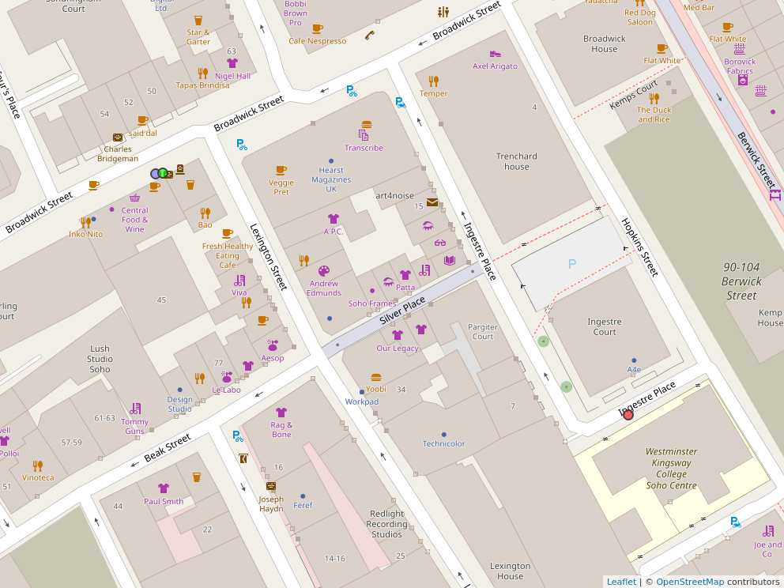

```r
knitr::include_graphics(system.file("misc/snow.png", package="rgdal"))
```

## Rebuilding CRS objects

Package authors of the almost 150 packages with **sp** objects with outdated `"CRS"` objects stored in `*.rda` or `*RData` files as data sets should update the `"proj4string"` slots of these objects and re-store. The `GGHB.IG` data set in the **CARBayesdata** package (version 2.1) can serve as an example.

```r
# library(CARBayesdata)
library(sp)
# data(GGHB.IG)
# orig <- slot(GGHB.IG, "proj4string")
(load(system.file("misc/GGHB.IG_CRS.rda", package="rgdal")))
```

```
## [1] "orig"
```

```r
orig
```

```
## Coordinate Reference System:
## Deprecated Proj.4 representation:
##  +proj=tmerc +lat_0=49 +lon_0=-2 +k=0.9996012717 +x_0=400000
## +y_0=-100000 +datum=OSGB36 +units=m +no_defs +ellps=airy
## +towgs84=446.448,-125.157,542.060,0.1502,0.2470,0.8421,-20.4894
```

The original `"CRS"` object contains a `+datum=` key (deprecated in GDAL’s `exportToProj4()` from GDAL 3) and a `+towgs84=` key, the handling of which has varied in different releases of PROJ >= 6 and GDAL 3. From **rgdal** 1.5-17 (development version), a PROJ function `proj_get_source_crs` is used by default, but may be avoided by setting the `sp::CRS()` `get_source_if_boundcrs=` argument to FALSE. The function will return the source CRS of a `BOUNDCRS` object. In some versions of PROJ/GDAL, the inclusion of a `+towgs84=` key is taken as meaning that the user wishes to create an object with the given source CRS, but because a `+towgs84=` key is present, it is assumed that the target is `WGS 84` with the given transformation method. Proj4 strings with `+towgs84=` keys have no authority for the parameters given, and do not harmonise with the use of the EPSG database.

To run the examples, we need the current development version of **sp** from `"rsbivand/sp"`:

```r
sp_version_ok <- length(grep("get_source_if_boundcrs", deparse(args(sp::CRS)))) > 0L
```

Running `sp::CRS()` takes the original Proj4 key-value pairs, and converts them into a WKT2 representation as well as returning an (unused) Proj4 string. This is kept in place for packages still expecting to see/use it, but all **rgdal** functions and methods use the WKT2 representation. Here, we do not try to handle the `BOUNDCRS` special case, something that leads to difficulties with some versions of PROJ later in workflows. The `BOUNDCRS` contains a `SOURCECRS` and a `TARGETCRS` (which also has swapped axes), while really all that was needed was the contents of the `SOURCECRS`:

```r
orig1 <- CRS(slot(orig, "projargs"), get_source_if_boundcrs=FALSE)
cat(wkt(orig1), "\n")
```

```
## BOUNDCRS[
##     SOURCECRS[
##         PROJCRS["unknown",
##             BASEGEOGCRS["unknown",
##                 DATUM["OSGB 1936",
##                     ELLIPSOID["Airy 1830",6377563.396,299.3249646,
##                         LENGTHUNIT["metre",1]],
##                     ID["EPSG",6277]],
##                 PRIMEM["Greenwich",0,
##                     ANGLEUNIT["degree",0.0174532925199433],
##                     ID["EPSG",8901]]],
##             CONVERSION["unknown",
##                 METHOD["Transverse Mercator",
##                     ID["EPSG",9807]],
##                 PARAMETER["Latitude of natural origin",49,
##                     ANGLEUNIT["degree",0.0174532925199433],
##                     ID["EPSG",8801]],
##                 PARAMETER["Longitude of natural origin",-2,
##                     ANGLEUNIT["degree",0.0174532925199433],
##                     ID["EPSG",8802]],
##                 PARAMETER["Scale factor at natural origin",0.9996012717,
##                     SCALEUNIT["unity",1],
##                     ID["EPSG",8805]],
##                 PARAMETER["False easting",400000,
##                     LENGTHUNIT["metre",1],
##                     ID["EPSG",8806]],
##                 PARAMETER["False northing",-100000,
##                     LENGTHUNIT["metre",1],
##                     ID["EPSG",8807]]],
##             CS[Cartesian,2],
##                 AXIS["(E)",east,
##                     ORDER[1],
##                     LENGTHUNIT["metre",1,
##                         ID["EPSG",9001]]],
##                 AXIS["(N)",north,
##                     ORDER[2],
##                     LENGTHUNIT["metre",1,
##                         ID["EPSG",9001]]]]],
##     TARGETCRS[
##         GEOGCRS["WGS 84",
```

[output cut: 15 more lines]

```
##             ID["EPSG",9606]],
##         PARAMETER["X-axis translation",446.448,
##             ID["EPSG",8605]],
##         PARAMETER["Y-axis translation",-125.157,
##             ID["EPSG",8606]],
##         PARAMETER["Z-axis translation",542.06,
##             ID["EPSG",8607]],
##         PARAMETER["X-axis rotation",0.1502,
##             ID["EPSG",8608]],
##         PARAMETER["Y-axis rotation",0.247,
##             ID["EPSG",8609]],
##         PARAMETER["Z-axis rotation",0.8421,
##             ID["EPSG",8610]],
##         PARAMETER["Scale difference",0.9999795106,
##             ID["EPSG",8611]]]]
```

Using the default setting to remove the unintended `BOUNDCRS` representation, we can get what was (probably) intended (when the **sp** version is as was before this work-around was added, the following two chunks yield `BOUNDCRS` for some versions of PROJ/GDAL:

```r
orig1a <- CRS(slot(orig, "projargs"))
cat(wkt(orig1a), "\n")
```

```
## BOUNDCRS[
##     SOURCECRS[
##         PROJCRS["unknown",
##             BASEGEOGCRS["unknown",
##                 DATUM["OSGB 1936",
##                     ELLIPSOID["Airy 1830",6377563.396,299.3249646,
##                         LENGTHUNIT["metre",1]],
##                     ID["EPSG",6277]],
##                 PRIMEM["Greenwich",0,
##                     ANGLEUNIT["degree",0.0174532925199433],
##                     ID["EPSG",8901]]],
##             CONVERSION["unknown",
##                 METHOD["Transverse Mercator",
##                     ID["EPSG",9807]],
##                 PARAMETER["Latitude of natural origin",49,
##                     ANGLEUNIT["degree",0.0174532925199433],
##                     ID["EPSG",8801]],
##                 PARAMETER["Longitude of natural origin",-2,
##                     ANGLEUNIT["degree",0.0174532925199433],
##                     ID["EPSG",8802]],
##                 PARAMETER["Scale factor at natural origin",0.9996012717,
##                     SCALEUNIT["unity",1],
##                     ID["EPSG",8805]],
##                 PARAMETER["False easting",400000,
##                     LENGTHUNIT["metre",1],
##                     ID["EPSG",8806]],
##                 PARAMETER["False northing",-100000,
##                     LENGTHUNIT["metre",1],
##                     ID["EPSG",8807]]],
##             CS[Cartesian,2],
##                 AXIS["(E)",east,
##                     ORDER[1],
##                     LENGTHUNIT["metre",1,
##                         ID["EPSG",9001]]],
##                 AXIS["(N)",north,
##                     ORDER[2],
##                     LENGTHUNIT["metre",1,
##                         ID["EPSG",9001]]]]],
##     TARGETCRS[
##         GEOGCRS["WGS 84",
```

[output cut: 15 more lines]

```
##             ID["EPSG",9606]],
##         PARAMETER["X-axis translation",446.448,
##             ID["EPSG",8605]],
##         PARAMETER["Y-axis translation",-125.157,
##             ID["EPSG",8606]],
##         PARAMETER["Z-axis translation",542.06,
##             ID["EPSG",8607]],
##         PARAMETER["X-axis rotation",0.1502,
##             ID["EPSG",8608]],
##         PARAMETER["Y-axis rotation",0.247,
##             ID["EPSG",8609]],
##         PARAMETER["Z-axis rotation",0.8421,
##             ID["EPSG",8610]],
##         PARAMETER["Scale difference",0.9999795106,
##             ID["EPSG",8611]]]]
```

The `sp::rebuild_CRS()` method for `"CRS"` objects (and thus that for `"Spatial"` objects) can be used to do the same as using `sp::CRS()` directly, with special treatment for a number of other objects inheriting from `"Spatial"`:

```r
orig1b <- rebuild_CRS(orig)
cat(wkt(orig1b), "\n")
```

```
## BOUNDCRS[
##     SOURCECRS[
##         PROJCRS["unknown",
##             BASEGEOGCRS["unknown",
##                 DATUM["OSGB 1936",
##                     ELLIPSOID["Airy 1830",6377563.396,299.3249646,
##                         LENGTHUNIT["metre",1]],
##                     ID["EPSG",6277]],
##                 PRIMEM["Greenwich",0,
##                     ANGLEUNIT["degree",0.0174532925199433],
##                     ID["EPSG",8901]]],
##             CONVERSION["unknown",
##                 METHOD["Transverse Mercator",
##                     ID["EPSG",9807]],
##                 PARAMETER["Latitude of natural origin",49,
##                     ANGLEUNIT["degree",0.0174532925199433],
##                     ID["EPSG",8801]],
##                 PARAMETER["Longitude of natural origin",-2,
##                     ANGLEUNIT["degree",0.0174532925199433],
##                     ID["EPSG",8802]],
##                 PARAMETER["Scale factor at natural origin",0.9996012717,
##                     SCALEUNIT["unity",1],
##                     ID["EPSG",8805]],
##                 PARAMETER["False easting",400000,
##                     LENGTHUNIT["metre",1],
##                     ID["EPSG",8806]],
##                 PARAMETER["False northing",-100000,
##                     LENGTHUNIT["metre",1],
##                     ID["EPSG",8807]]],
##             CS[Cartesian,2],
##                 AXIS["(E)",east,
##                     ORDER[1],
##                     LENGTHUNIT["metre",1,
##                         ID["EPSG",9001]]],
##                 AXIS["(N)",north,
##                     ORDER[2],
##                     LENGTHUNIT["metre",1,
##                         ID["EPSG",9001]]]]],
##     TARGETCRS[
##         GEOGCRS["WGS 84",
```

[output cut: 15 more lines]

```
##             ID["EPSG",9606]],
##         PARAMETER["X-axis translation",446.448,
##             ID["EPSG",8605]],
##         PARAMETER["Y-axis translation",-125.157,
##             ID["EPSG",8606]],
##         PARAMETER["Z-axis translation",542.06,
##             ID["EPSG",8607]],
##         PARAMETER["X-axis rotation",0.1502,
##             ID["EPSG",8608]],
##         PARAMETER["Y-axis rotation",0.247,
##             ID["EPSG",8609]],
##         PARAMETER["Z-axis rotation",0.8421,
##             ID["EPSG",8610]],
##         PARAMETER["Scale difference",0.9999795106,
##             ID["EPSG",8611]]]]
```

In practice, `sp::rebuild_CRS()` methods may be used, but users should check the output for coherence, and the PROJ function for extracting `SOURCECRS` from `BOUNDCRS` avoided if it has unfortunate consequences.

### References

Brody, H., M. R. Rip, P. Vinten-Johansen, N. Paneth, and S. Rachman. 2000. “Map-Making and Myth-Making in Broad Street: The London Cholera Epidemic, 1854.” *Lancet* 356: 64–68.

Evenden, Gerald I. 1990. *Cartographic Projection Procedures for the UNIX Environment — a User’s Manual*. http://download.osgeo.org/proj/OF90-284.pdf.

Evers, Kristian, and Thomas Knudsen. 2017. *Transformation Pipelines for PROJ.4*. https://www.fig.net/resources/proceedings/fig_proceedings/fig2017/papers/iss6b/ISS6B_evers_knudsen_9156.pdf.

Iliffe, Jonathan, and Roger Lott. 2008. *Datums and Map Projections: For Remote Sensing, GIS and Surveying*. Boca Raton: CRC.

ISO. 2019. *ISO 19111:2019 Geographic Information – Referencing by Coordinates*. https://www.iso.org/standard/74039.html.

Knudsen, Thomas, and Kristian Evers. 2017. *Transformation Pipelines for PROJ.4*. https://meetingorganizer.copernicus.org/EGU2017/EGU2017-8050.pdf.